# HW2

Group 8

28 May 2024

Group :

Lisa Bensousan - 346462534 - lisa.bensoussan@mail.huji.ac.il  
Dan Levy - 346453202 - dan.levy5@mail.huji.ac.il  
Emmanuelle Fareau - 342687233 - emmanuel.fareau@mail.huji.ac.il

### Libraries used :

```r
if (!require('data.table')){
  install.packages('data.table')
  library('data.table')
}
library('tictoc')
if (!require('manipulate')){
  install.packages('manipulate')
  library('manipulate')
}
if (!require("fitdistrplus")) install.packages("fitdistrplus")
```

```r
library(data.table)
library(ggplot2)
library(fitdistrplus)
```

### Paths and Data :

We are loading the data in our R file.

```r
reads_file <- "/Users/lisabensoussan/Desktop/Lab2/TCGA-13-0723-01A_lib1_all_chr1.forward"
```

## Introduction :

In this exercise we are interested in the frequency of appearance of the number of reads in the positions on chromosome 1 . We try to see if there is something that repeats according to their distribution. The goal will also be to agree to this distribution the normal law that is most approaching.

## Part 1:

We use `fread` to read data. Then, we use `head` to get an overview of our data and see if it downloaded correctly.

```r
chr1_reads = fread(reads_file)

head(chr1_reads)
```

```
##       V1    V2    V3
##    <int> <int> <int>
## 1:     1    28   153
## 2:     1    35   184
## 3:     1    35   177
## 4:     1    36   186
## 5:     1    37     0
## 6:     1    37   242
```

We rename columns of our data with `colnames` to make it easier to use and understand.

```r
colnames(chr1_reads) = c("Chrom","Loc","FragLen")
head(chr1_reads)
```

```
##    Chrom   Loc FragLen
##    <int> <int>   <int>
## 1:     1    28     153
## 2:     1    35     184
## 3:     1    35     177
## 4:     1    36     186
## 5:     1    37       0
## 6:     1    37     242
```

```r
chr1_reads[sample(nrow(chr1_reads),10)] #Just consider a simple of size 10
```

```
##     Chrom       Loc FragLen
##     <int>     <int>   <int>
##  1:     1 152761985     188
##  2:     1  39404441     147
##  3:     1 236084769     139
##  4:     1 181453795     159
##  5:     1  29075625     142
##  6:     1   9930340     152
##  7:     1 238881869     149
##  8:     1   8272004     120
##  9:     1 121036639     162
## 10:     1 233852423     162
```

Our goal in this part is to create a function that takes two parameters: a start point and an end point. It calculates for each base between the two points the number of fragments beginning with this point.

For this, we create function to count the start of fragments. In this function, we filter the data for the specific chromosome and range, we create a vector for counts initialized to zero, then we tabulate starts within the range with function `table`. After this, we place counter in the corresponding positions.

```r
count_fragment_starts <- function(data, chrom_number, start_range, end_range) {
  relevant_data <- data[Chrom == chrom_number & Loc >= start_range & Loc <= end_range,]
  start_counts <- integer(end_range - start_range + 1)
  names(start_counts) <- as.character(start_range:end_range)

  starts <- table(relevant_data$Loc)

  start_positions <- as.character(names(starts))
  start_counts[start_positions] <- as.integer(starts)

  return(start_counts)
}
```

Thanks to this function, we do the sum of fragments and printing the results.

```r
tic()
fragment_counts <- count_fragment_starts(chr1_reads, 1, 0, 20000000)
toc()
```

```
## 11.449 sec elapsed
```

```r
total_fragments <- sum(fragment_counts)
total_fragments
```

```
## [1] 1357997
```

```r
# Example of using the function on a smaller range for demonstration
small_range_counts <- count_fragment_starts(chr1_reads, 1, 0, 1000)
print(small_range_counts)
```

```
##    0    1    2    3    4    5    6    7    8    9   10   11   12   13   14   15
##    0    0    0    0    0    0    0    0    0    0    0    0    0    0    0    0
##   16   17   18   19   20   21   22   23   24   25   26   27   28   29   30   31
##    0    0    0    0    0    0    0    0    0    0    0    0    1    0    0    0
##   32   33   34   35   36   37   38   39   40   41   42   43   44   45   46   47
##    0    0    0    2    1    2    0    1    3    2    1    2    2    2    2    0
##   48   49   50   51   52   53   54   55   56   57   58   59   60   61   62   63
##    2    2    1    0    2    2    3    1    1    3    2    2    3    2    1    1
##   64   65   66   67   68   69   70   71   72   73   74   75   76   77   78   79
##    2    2    2    0    3    3    0    1    0    1    2    1    0    0    0    0
##   80   81   82   83   84   85   86   87   88   89   90   91   92   93   94   95
##    0    0    0    0    0    0    0    0    0    0    0    0    0    0    0    0
##   96   97   98   99  100  101  102  103  104  105  106  107  108  109  110  111
##    0    1    0    0    0    0    0    0    1    0    0    0    0    0    0    0
##  112  113  114  115  116  117  118  119  120  121  122  123  124  125  126  127
```

[output cut: 111 more lines]

```r
# Measure the execution time for a smaller area
tic()
small_range_counts <- count_fragment_starts(chr1_reads, 1, 0, 1000)
toc()
```

```
## 0.739 sec elapsed
```

We successfully loaded the data and renamed the columns for better clarity. By examining a sample of the data, we ensured its integrity and correctness. We then developed a function, count_fragment_starts, which efficiently counts the number of fragments starting at each base within a specified range. Most of them are 0, but there are some 1 and 3 and very fews 3.

## Part 2 :

In this part, our aim is to create an histogram which represents the frequencies of the number of reads linked to bases .

```r
last_read <- max(chr1_reads$Loc)
total_reads <- nrow(chr1_reads)

coverage_estimate <- total_reads / last_read
beg_region <- 1
end_region <- 10000000
N <- end_region - beg_region + 1  # Total number of positions in the region of interest
read_starts <- rep(0, N)


tic()
filtered_reads <- chr1_reads[Loc >= beg_region & Loc <= end_region, .(Loc)]
for (r in filtered_reads$Loc) {
    read_starts[r - beg_region + 1] <- read_starts[r - beg_region + 1] + 1
}
toc()
```

```
## 2.525 sec elapsed
```

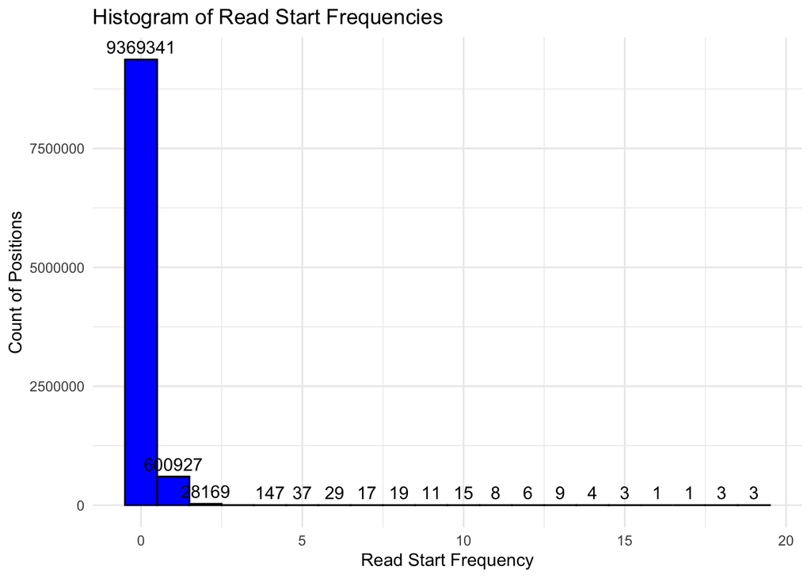

```r
coverage_data <- data.frame(Position = beg_region:end_region, ReadStarts = read_starts)

ggplot(coverage_data, aes(x = ReadStarts)) +
  geom_histogram(binwidth = 1, fill = "blue", color = "black") +
  labs(title = "Histogram of Read Start Frequencies",
       x = "Read Start Frequency",
       y = "Count of Positions") +
  theme_minimal() +
  geom_text(stat='count', aes(label=..count..), vjust=-0.5, check_overlap = TRUE)
```

We calculated the read start frequencies across the first 10 million bases of chromosome 1. Using these frequencies, we generated a histogram to visualize the distribution. The histogram revealed that the majority of positions have a low frequency of read starts, with a few positions having significantly higher counts. This indicates a non-uniform distribution of reads across the analyzed region.

# Part 3 :

In this section, we want to create a function that calculates the sums of fragment lengths per cell.

So to do this we create a variable cell size and we will divide our data according to this variable. Then we calculate the sum of the fragments. We create a new column `TotalFragLen` which contains the sum of the fragment lengths (FragLen) for each cell.

```r
summarize_fragments <- function(chr1_reads, cell_size) {

  chr1_reads[, Cell := floor(Loc / cell_size)]

  result <- chr1_reads[, .(TotalFragLen = sum(FragLen)), by = Cell]

  return(result)
}
```

We test our function on our data and with cell size of 50 000.

```r
result <- summarize_fragments(chr1_reads, 50000)
print(result)
```

```
##        Cell TotalFragLen
##       <num>        <num>
##    1:     0        67946
##    2:     1    666288489
##    3:     2        11471
##    4:     3         1183
##    5:     4       103011
##   ---
## 4532:  4939       216628
## 4533:  4940       222170
## 4534:  4941    -14722586
## 4535:  4942       413977
## 4536:  4943       329484
```

# Question a :

We want to create a graph describing the distribution on the chromosome with the number of fragments in relation to the location of the cells.  
So we use the function that we have create in the previous question and apply `ggplot` function.

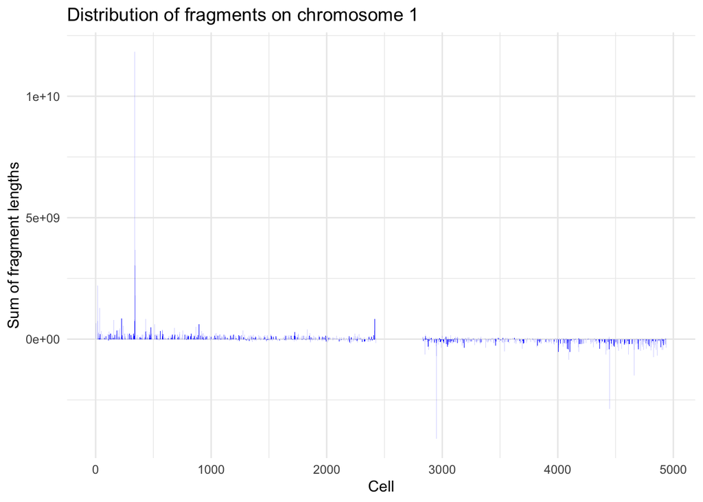

```r
ggplot(result, aes(x = Cell, y = TotalFragLen)) +
  geom_bar(stat = "identity", fill = "blue") +
  labs(title = "Distribution of fragments on chromosome 1",
       x = "Cell",
       y = "Sum of fragment lengths") +
  theme_minimal()
```

# Question b :

We would like to present a second graph representing the distribution in a window of 20 million bases (a zoom in on the first), which will allow us to better understand the distribution of the number of fragments.

We define the window star, window end and the cell size. We calculate the cell number corresponding to the end of the window with $\frac{window \: end}{cell size}$. Then, we filter data for the 20 million base window.

After this, we can create our plot with `ggplot`.

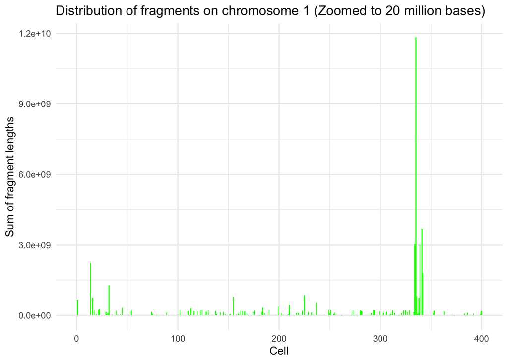

```r
cell_size <- 50000
window_start <- 0
window_end <- 20000000

cell_end <- window_end / cell_size

filtered_result <- result[Cell >= window_start & Cell <= cell_end]

ggplot(filtered_result, aes(x = Cell, y = TotalFragLen)) +
  geom_bar(stat = "identity", fill = "green") +
  labs(title = "Distribution of fragments on chromosome 1 (Zoomed to 20 million bases)",
       x = "Cell",
       y = "Sum of fragment lengths") +
  theme_minimal()
```

Thanks to this zoom, we can to see with more precision the plot and to better understand the distribution of the number of fragments. We can notice a spike in the number of fragments towards cells 330 to 340. And around cells 60 and 260 we can notice a total absence of peak.

# Part 4 :

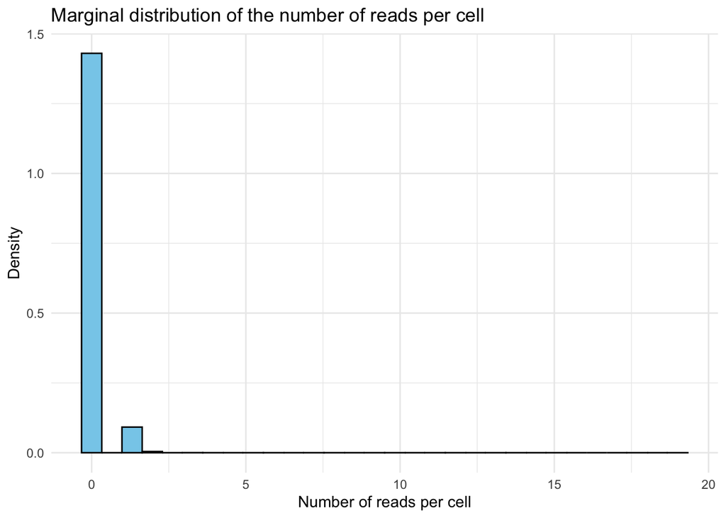

```r
ggplot(coverage_data, aes(x = ReadStarts)) +
  geom_histogram(aes(y = ..density..), bins = 30, fill = "skyblue", color = "black") +
  labs(title = "Marginal distribution of the number of reads per cell",
       x = "Number of reads per cell",
       y = "Density") +
  theme_minimal()
```

We want to fit a normal distribution to the data. For this we use the `fitdist` function in R. Then we add the fitted normal distribution curve to the graph created previously.

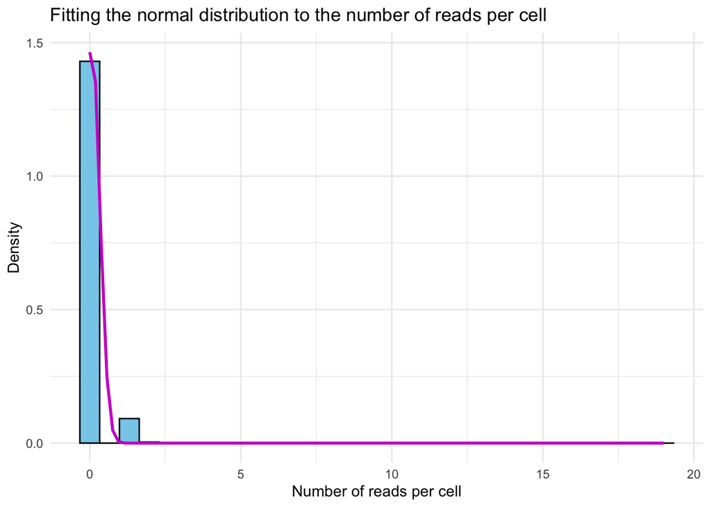

```r
fit <- fitdist(coverage_data$ReadStarts, "norm")

ggplot(coverage_data, aes(x = ReadStarts)) +
  geom_histogram(aes(y = ..density..), bins = 30, fill = "skyblue", color = "black") +
  stat_function(fun = dnorm, args = list(mean = fit$estimate["mean"], sd = fit$estimate["sd"]), color = "magenta3", size = 1) +
  labs(title = "Fitting the normal distribution to the number of reads per cell",
       x = "Number of reads per cell",
       y = "Density") +
  theme_minimal()
```

```r
print(fit)
```

```
## Fitting of the distribution ' norm ' by maximum likelihood
## Parameters:
##       estimate   Std. Error
## mean 0.0663004 8.349065e-05
## sd   0.2640206 5.903299e-05
```

## Short summary :

In this exercise, we aimed to analyze the distribution of read fragments on chromosome 1 to identify any recurring patterns. Our analysis was divided into several key parts, each contributing to a comprehensive understanding of the data.

Overall, our analysis highlighted the non-uniform distribution of read fragments along chromosome 1. The variability in fragment counts across cells and the fit of a normal distribution to the number of reads per cell provide insights into the underlying patterns of our genomic data. This study showcases the importance of thorough data exploration and visualization in understanding complex biological datasets.

By following the structured approach outlined in this document, we were able to effectively analyze and interpret the distribution of read fragments, providing a solid foundation for further genomic studies.